# Essential Statistics

PhD+ 2023: Data Literacy in R  
2023-03-29

Clay Ford, UVA Library

## Data Literacy

> data literacy…describes the ability to not only carry out statistical analysis on real world problems, but also to understand and critique any conclusions drawn by others on the basis of statistics.

David Spiegelhalter, *The Art of Statistics*

## Hold the bacon?

In 2015 the World Health Organization (WHO) [announced](https://www.who.int/news-room/questions-and-answers/item/cancer-carcinogenicity-of-the-consumption-of-red-meat-and-processed-meat) that eating 50g of processed meat a day was associated with an increased risk of bowel cancer of 18%.

How concerned should we be?

It depends. Is that an *absolute* increase or a *relative* increase?

## Absolute versus Relative

- Absolute is additive.
  - 2% + 18% = 20% (absolute increase of 18%)
  - 20% + -18% = 2% (absolute increase of decrease 18%)
- Relative is multiplicative.
  - 2% x (1 + 0.18) 1.18 = 2.36% (relative increase of 18%)
  - 20% x (1 - 0.18) 0.82 = 16.4% (relative decrease of 18%)

The 18% increase mentioned in the WHO study is *relative*.

If the risk (probability) of bowel cancer without consuming 50g of processed meat per day is 0.001, then an 18% increase raises the risk to 0.001 x 1.18 = 0.00118.

**Important**

Interpreting a relative increase as absolute can make it seem more important than it really is.

## Determining change

Given before and after proportions/percents…

- use subtraction to determine **absolute** change
- division (or a ratio) to determine **relative** change

Example: In 2014, 0.0694, or 6.94%, of U.S. households had at least one motorcycle. In 2018, that figure rose to 0.0802, or 8.02%. [source](https://www.prnewswire.com/news-releases/us-households-with-a-motorcycle-climbs-to-record-8-percent-in-2018-300783120.html)

**Absolute change**:  
Ownership increased by 8.02% - 6.94% = 1.08%  
The percentage of households increased from 6.94% to 8.02%

**Relative change**:  
Ownership increased by 8.02/6.94 = 1.1556 (or 15.56%)  
The 2014 percentage increased by 15.56%

## Proportions versus Percents

Proportions range from 0 to 1. (eg, 0.18)

Percents are proportions multiplied by 100 with a % sign appended to the value. (0.18 x 100 = 18%)

Most any statistical program is going to return *proportions*.

**Important**

Beware of confusing proportions with percents. Example: confusing a percent risk of 0.5% as a proportion (probability) of 0.5 (instead of 0.005)

**Important**

Beware of importing data with percents into R. The percent symbols can result in numbers being treated as character data.

## Don’t forget the denominator

When used to summarize data, Percents and Proportions are both relative to the size of the data, which is in the denominator.

Example: 0.14, or 14%, of students surveyed said they were cancelling Netflix.

That could be 1/7, or 100/700. The former seems less important because of the small denominator.

**Important**

Beware of percents and proportions presented without the denominator (sample size) used to calculate them.

**Important**

Also consider the source of the denominator. Was the survey random or administered in the dining hall during breakfast?

## Probability versus Odds

Probabilities (p) range from 0 to 1. Proportions are often interpreted as estimates of probabilities.

Odds = p/(1 - p) and range from 0 to infinity.

If the probability of rain tomorrow is 0.2, the odds are 0.2/(1 - 0.2) = 1/4.

If the probability of rain tomorrow is 0.8, the odds are 0.8/(1 - 0.8) = 4.

**Important**

Beware of expressing or interpreting probabilities as odds and vice versa.

Let’s go to R.

## Our brains can’t handle this

```r
head(d$totalvalue, n = 200)
```

```
  [1] 2291600 1864600 4512500 2278600 2271900 1404000 2019500 1643600 1626900
 [10] 2064500 2846500 3012100 2524700 2871100 3002100 3002300 3719600 7749000
 [19] 2173200 3970800 3534400 5951400 1902300 2665200 2367100 1785700 1789700
 [28] 4287700 3132600 4872600 2086900 3689700 2521800 2601000 1489100 2527900
 [37] 5832500 2931200 4863200 4342600 3447200 3541400 3625700 2553100 2056600
 [46] 2228800  660800 3121000 1425900 2158100 2482400 2847900 1738300 1661600
 [55] 1298100 3464400 3327200 2171000 1240100 2058400 6935200 3191800  388800
 [64] 1669800 2599500 1622700  827300  815100  718900  564100  713400 4050800
 [73] 2293600 1992100 4202700 2396300 4515300  386300 2715300 3266300 3961400
 [82] 2097700 4456900 2504300 2610600 1871000 1771000  622500 1871800 4291900
 [91] 1057900 2257600 3591300  228300  264600  247100  241000  249300  265900
[100]  263200  262200  278200  185600  246500  247100  270000  278200  261400
[109]  247100  247100  248500  247100  247700  243600  264100  264200  266500
[118]  251600  244300  252300  247600  260200  262000  269100  247100  260200
[127]  257500  263200  260800  261400  266300  266600  243900  264600  246400
[136]  290700  262200  244300  276500  247100  247100  246400  250400  298000
[145]  263300  249000  247300  252100  283800  283300  261000  263600  248100
[154]  241100  287900  268600  268600  213100  254100  258800  267900  269600
[163]  245700  250600  251400  266600  266500  249700  271700  249700  262300
[172]  268500  250700  251900  249800  252600  262700  270000  248700  501300
[181]  252600  251400  246300  270600  266800  225500  213900  254200  250700
[190]  275400  268400  256200  281900  251400  250800  274600  463400  287800
[199]  265800  273100
```

## Center and Spread

We usually summarize numeric data by calculating some measure of the center and the spread.

- *Center* is usually interpreted as a typical or representative value. That’s not always correct.
- *Spread* is usually interpreted as how far away we can expect any value to be from the center value. That’s not always useful.

The most common measures of center are the **mean** and **median**.

The most common measures of spread are the **standard deviation (SD)** and **interquartile range (IQR)**.

## Mean and Median

The mean is the point at which the data would balance on a fulcrum.

The median is the middle point of data sorted in ascending order.

When data are *symmetric*, the mean and median are close.

When data are *skewed*, the median may be a better measure of center or typical value.

**Tip**

You can examine and present both means and medians. You don’t have to pick one.

**Important**

Means and medians as summary measures are not always the best estimates of the expected or most representative value.

## Some distributions

Mean and Median

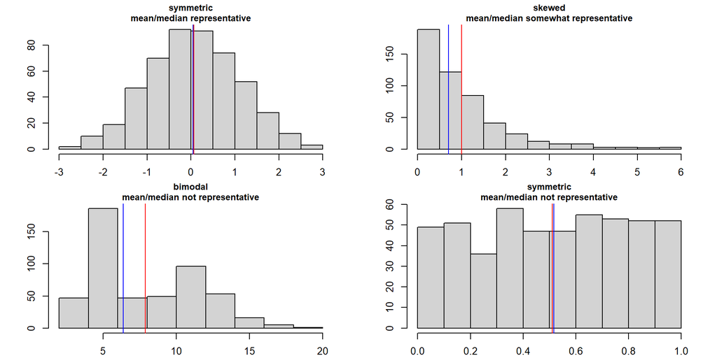

## Standard Deviation and IQR

Standard Deviation is basically how far a given value is expected to be from the mean. It’s really only appropriate for symmetric data. Like the mean, it can be easily influenced by extreme values.

IQR is the difference between the 75th and 25th percentiles. It contains the middle 50% of the data. It is unaffected by extreme values.

```r
sd(d$totalvalue)
```

```
[1] 399247.2
```

```r
IQR(d$totalvalue)
```

```
[1] 281600
```

As summaries of data, they can be confusing if your audience is not familiar with the concept of spread.

**Tip**

Data with no variability has a standard deviation/IQR of 0. SD/IQR is $\ge 0$

## Percentiles/Quantiles/Quartiles

Observe the summary output for Albemarle Real Estate home values:

```r
summary(d$totalvalue)
```

```
   Min. 1st Qu.  Median    Mean 3rd Qu.    Max.
   4200  298600  407000  504881  580200 8869000
```

The value labeled “1st Qu.”, $298,600, is the 1st quartile, 0.25 quantile, and 25th percentile.

- 1st quartile = the value below which lies one quarter (1/4) of the data
- 0.25 quantile = the value below which lies 0.25 of data
- 25th percentile = the value below which lies 25% of data

The median is the 2nd quartile, 0.5 quantile, and 50th percentile. “3rd Qu.” is the 3rd quartile, 0.75 quantile, and 75th percentile.

The `quantile()` function returns the quantile/percentile you specify.

## Empirical Cumulative Distributions

The output below says homes valued at $855,430 are in the 90th percentile of homes. 90% of homes are valued lower.

```r
quantile(d$totalvalue, probs = 0.90)
```

```
   90%
855430
```

What percentile is a home valued at $350,000 in? To answer this we need to determine the *Empirical cumulative distribution*. R makes this relatively easy with the `ecdf()` function.

The `ecdf()` function actually creates a function from your data. You then use that function to get the quantile/percentile of a given data point.

```r
Fn <- ecdf(d$totalvalue)
Fn(350000)
```

```
[1] 0.3703174
```

A home valued at $350,000 is in about the 37th percentile.

## Transforming data

Transforming data to a different scale can reduce the impact of extreme values. A common transformation is the *log* transformation.

This basically translates data into *magnitudes*.

```r
x <- c(10, 100, 1000, 10000, 100000, 1000000)
log10(x) # what power do we raise 10 to get x? Log base 10
```

```
[1] 1 2 3 4 5 6
```

```r
log(x) # what power do we raise e to get x? Natural log
```

```
[1]  2.302585  4.605170  6.907755  9.210340 11.512925 13.815511
```

Natural logs are often preferred in statistical analyses because they can make interpretation easier.

They are also appropriate when large data values can be assumed to be bigger in a *relative* sense rather than an *absolute* sense. (Managers earn 20% more than workers. Directors earn 30% more than managers. Executives earn 40% more than Directors. And so on.)

## Before and After

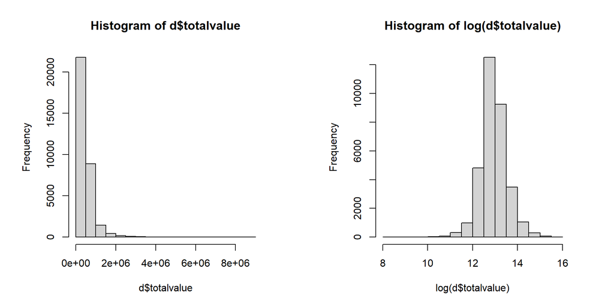

**Tip**

Log transformations only work for positive data.

## Summarizing two sets of values

Below is a scatterplot of 200 randomly sampled homes from Albemarle County comparing total value to finished sq ft. How can we summarize this relationship?

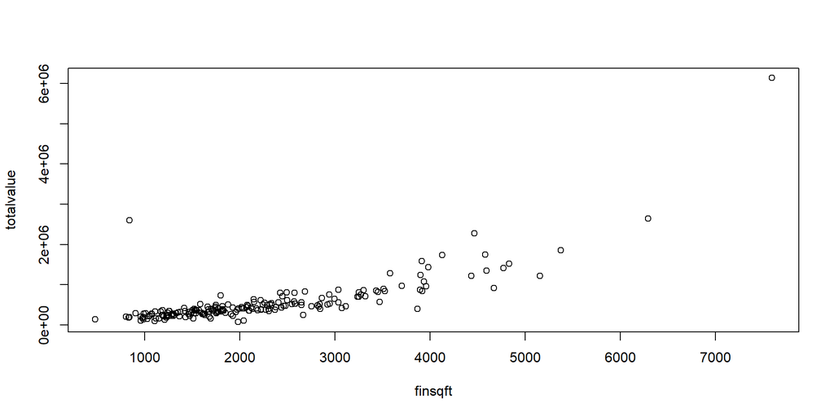

## Correlation

Correlation is a single value that can (sometimes) summarize a relationship between two sets of numeric data.

Correlation is unitless and ranges from -1 to 1. It expresses how close dots fall along a line. [See this useful Wikipedia illustration](https://en.wikipedia.org/wiki/Correlation_and_dependence#/media/File:Correlation_examples2.svg)

**Pearson** correlation measures linear association.  
**Spearman** *rank* correlation can measure non-linear association such as curved lines.

The correlation of the data in the previous plot can be calculated as follows:

```r
cor(samp_d$finsqft, samp_d$totalvalue, method = "pearson")
```

```
[1] 0.7649748
```

```r
cor(samp_d$finsqft, samp_d$totalvalue, method = "spearman")
```

```
[1] 0.8476773
```

## Correlation warning

Correlations near 0 do not mean there is no relationship. Observe the following, courtesy of [The Datasaurus Dozen](https://github.com/jumpingrivers/datasauRus). Lesson: plot your data. Let’s go to R!

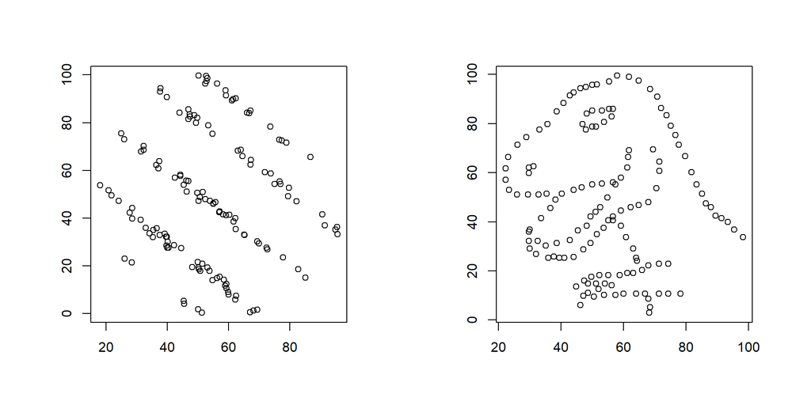

```r
cor(dat$slant_down_x, dat$slant_down_y) # slanting lines
```

```
[1] -0.06897974
```

```r
cor(dat$dino_x, dat$dino_y)  # t-rex
```

```
[1] -0.06447185
```

## Trees

> “we estimate that the global number of trees is approximately 3.04 trillion (+/-0.096 trillion, 95% confidence interval (CI))”

Mapping tree density at a global scale, [Nature](https://www.nature.com/articles/nature14967) (2015)

## Uncertainty

Sometimes we can collect all the data in a population (eg, Albemarle County real estate data). The mean of the data is the mean. There is no uncertainty.

Sometimes we can only collect a sample (eg, voters, trees, cows). Hopefully it’s a *random sample*. The mean of the sample data is *not* the mean of the entire population. It is an *estimate*.

We often use the estimate as our best guess at the population mean. How uncertain is this estimate?

We usually try to assess this with *standard errors* and *confidence intervals*.

## Standard Errors

Imagine randomly sampling 30 UVA students, weighing their backbacks, and taking the mean weight. And then sampling 30 more students and getting another mean. And again, and again, thousands of times, getting more means.

Now calculate the standard deviation of those means. That’s the *standard error*.

The standard deviation of the sample means summarizes the uncertainty of our sample mean.

In practice, we don’t take thousands of means. We take one and we usually calculate standard error using a formula such as $SD_{\text{sample}}/\sqrt{n}$.

For example, a [study](https://www.sciencedirect.com/science/article/pii/S2314853516300555) estimated the mean weight of chicken eggs to be about 55.02g with a standard error of 0.40 when the chicken was 25 weeks old.

**Important**

Be cautious of interpreting estimates presented without standard errors.

## The Central Limit Theorem

Previously we saw distributions of *raw data* for which the standard deviation was not a good measure of spread.

However it turns out the distribution of sample means calculated from most distributions is fairly symmetric. This is the *Central Limit Theorem*. This means we can be fairly confident about standard error estimates.

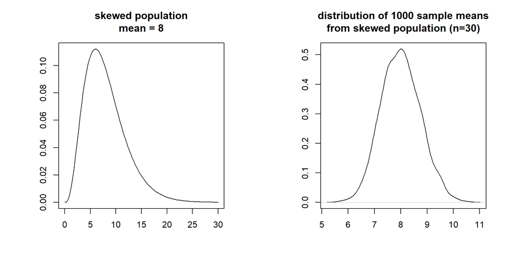

## Confidence Intervals

Adding and subtracting standard errors to our estimate forms an interval of what we might say is a reasonable range that contains the true population value.

The most common interval calculated is the *95% confidence interval* (CI).

We say “95%” because the method should work 95% of the time based on the number of standard errors we add/subtract to create the interval.

We call it “confidence” because we are confident in the method.

## Confident in the process

If we were to take thousands of samples and calculate thousands of 95% confidence intervals, about 95% of the intervals should contain the true value.

The 95% confidence interval on the number of trees (in trillions) was [2.94, 3.14]. That interval either contains the true number or it does not.

**Important**

A confidence interval is *not* a probability interval. Do not say there is a 95% probability the value is between the lower and upper bounds.

Let’s go to R.

## Cow painting

> “The total numbers of biting flies on the legs and body for B&W cows were almost half those on Control (p < 0.0001).” [paper](https://journals.plos.org/plosone/article?id=10.1371/journal.pone.0223447)

Painting ‘Zebra Stripes’ on Cows Wards Off Biting Flies [source](https://www.realclearscience.com/quick_and_clear_science/2019/10/07/painting_zebra_stripes_on_cows_wards_off_biting_flies.html)

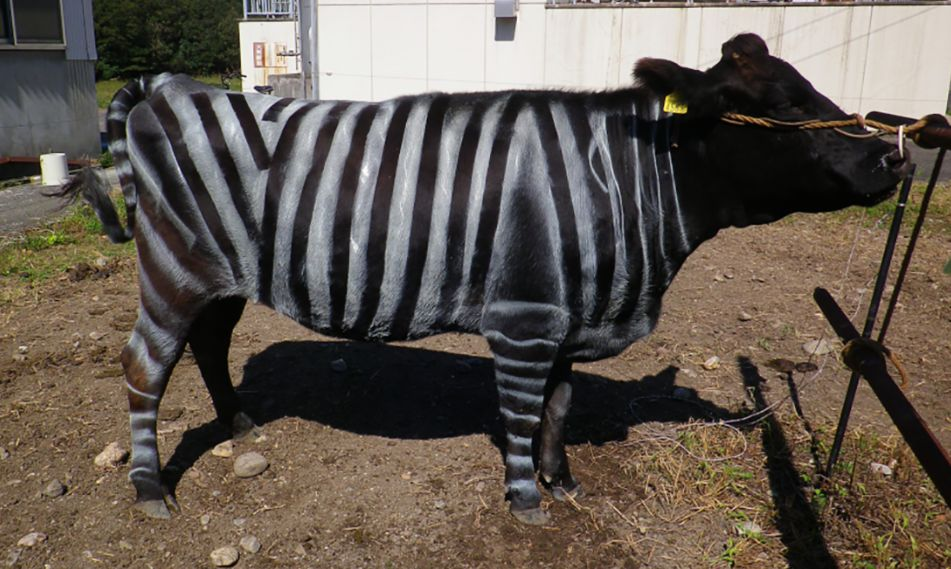

## Hypothesis testing and p-values

Let’s say we believe a coin is fair and lands heads 50% of the time.

We flip it 20 times and get 18 heads. That’s 18/20 = 0.90, or 90%.

If the coin was really fair, what is the probability of getting 18 *or more* heads?

The answer is about 0.0002. That’s a *p-value*.

That’s a small probability and leads us to reject the belief that the coin is fair.

What we just described is an example of a *hypothesis test*.

## Hypothesis testing and p-values

Hypothesis testing estimates the probability of obtaining the data we collected, or more extreme data, under the assumption of some hypothesis (usually a null/no effect hypothesis).

What is the probability a cow painted like a zebra would have 55 *or fewer* fly bites than an unpainted cow which had 128, *assuming the paint job had no effect*? The authors state p < 0.0001.

Historically, p-values < 0.05 have been interpreted as “statistically significant”, though many prominent statisticians are [now calling to abolish that threshold and the phrase “statistically significant”](https://www.tandfonline.com/doi/full/10.1080/00031305.2019.1583913).

Nevertheless, p-values have been published, and will likely continue to be published, so it pays to know what they mean.

**Tip**

When you see a p-value, think “probability of the data, or more extreme data, assuming a null hypothesis was true.”

## p-values are slippery

P-values are often misinterpreted and misused.

1. They *do not* measure the probability the null hypothesis is true or that the data were produced by random chance alone.
2. They *do not* justify proof of something because they’re less than 0.05.
3. They *do not* prove the null hypothesis because they’re greater than 0.05.
4. They *do not* measure the size of an effect or the importance of a result.

See The American Statistical Association’s [special issue](https://www.tandfonline.com/doi/full/10.1080/00031305.2019.1583913) on p-values.

**Important**

P-values should not be revered as the final word in any analysis.

## The Frequentist view

Hypothesis testing, p-values, and confidence intervals assume there is a *fixed but unknown true value* we’re trying to estimate.

This is often called the **Frequentist** philosophy because p-values and confidence intervals summarize expected behavior in the *long run*.

**Example**: there is a true mean weight of student backpacks at UVA. Our sample and confidence interval is our attempt to estimate the range of the true mean. Repeated samples and confidence intervals will capture true mean 95% of the time.

**Example**: If painting cows like zebras has no effect on number of fly bites, we would expect to see the type of data we collected, or more extreme data, less than 0.0001 of the time.

## The Bayesian view

Another philosophical approach says forget estimating a value. Instead use expertise and common sense to hypothesize a *probability distribution* for a value of interest.

We then collect data and update our *prior* distribution to create a *posterior* distribution.

We then use our posterior distribution to summarize the value of interest.

This is called the **Bayesian** philosophy, after a Presbyterian minister named Thomas Bayes.

## A quick Bayesian example

Perhaps we think the average backpack weighs around 18 lbs. A possible *prior distribution* might be a Normal distribution with mean 18 and standard deviation of 5. (Fig 1)

After observing our data we use *Bayes’ theorem* to update our prior distribution to get a *posterior distribution*. (Fig 2)

We use our posterior distribution to calculate a *credible interval*. There’s about 0.74 probability that the mean backpack weight is between 15.5 and 16.5 lbs. (Fig 3)

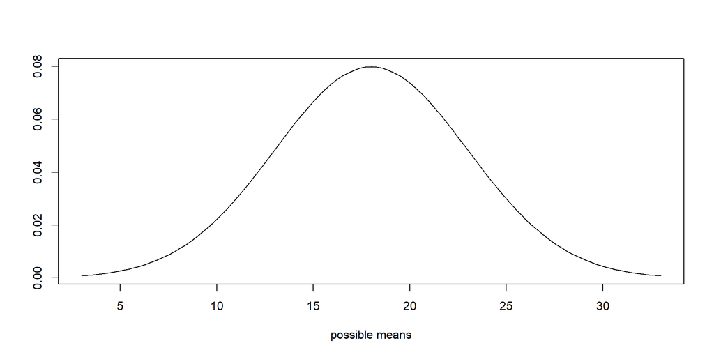

Figure 1: Prior Distribution

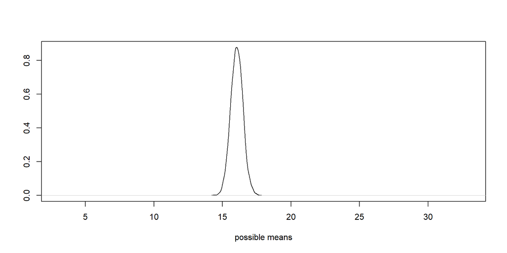

Figure 2: Posterior Distribution

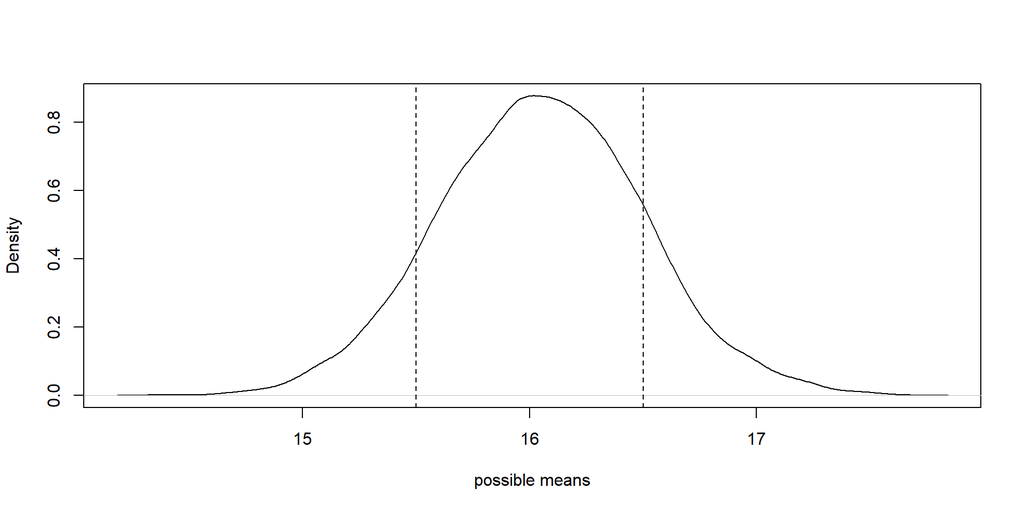

Figure 3: Credible Interval

## The truth about statistics

> Students are frequently left with the impression that statistics is a monolith, firmly rooted in mathematics and thus somehow pure — while in truth the subject is highly contentious and as closely aligned to philosophy as it is to math.

Darren Dahly, [Statistical Reform](https://statsepi.substack.com/p/statistical-reform)

Let’s go to R.

## Is education risky?

> Women with ≥3 years university education had increased risk of glioma (1.23, 1.08 to 1.40) and meningioma (1.16, 1.04 to 1.29) compared to those with primary education.

> Poisson regression models were used to calculate incidence rate ratios (IRR) for brain tumours by different indicators of socioeconomic position (SEP), with adjustment for potential confounders.

Socioeconomic position and the risk of brain tumour: a Swedish national population-based cohort study [source](https://jech.bmj.com/content/70/12/1222)

## Conditional means

The mean total value value of Albemarle homes is a little over $500,000.

```r
mean(d$totalvalue)
```

```
[1] 504880.8
```

But the mean total value of Albemarle homes when they have 1,280 finished square is much lower.

```r
mean(d$totalvalue[d$finsqft == 1280])
```

```
[1] 262617.3
```

But the mean total value of Albemarle homes when they have 1,280 finished square and they have central air is a little higher.

```r
mean(d$totalvalue[d$finsqft == 1280 & d$cooling == "Central Air"])
```

```
[1] 272134.7
```

The expected value of a home appears to depend on certain features.

## Linear Models

A *linear model* allows us to estimate expected values conditional on features or predictors.

A linear model is a function of predictors. For example, here’s a simple model:

$$\text{total value} = 80,839 + 111\text{ finsqft} + 49,396 \text{ cooling}$$

This model estimates the mean expected value of homes with 2000 finished square feet and central air (cooling = 1) to be $352,235 :

$$\text{total value} = 80,839 + 111(2000) + 49,396(1) = \$ 352,235$$

It says each additional finished square foot adds $111 to the expected value of a home. It also says a home with central air is expected to be worth almost $50,000 more than a home without central air.

If we were interested in finsqft, we might say we have adjusted for the potential confounder cooling.

## No model is perfect

A linear model attempts to *approximate* the process that generated the data. It will always be wrong and uncertain, but hopefully it will be useful.

We pick the model.

If we are satisfied with the model, we can use it to make predictions or summarize associations.

This is also referred to as *Multiple Regression* or *Regression Modeling*.

## Model uncertainty

Consider this model again:

$$\text{total value} = 80,839 + 111\text{ finsqft} + 49,396 \text{ cooling}$$

- The model may be bad. (Wrong predictors, left out predictors, not additive.)
- The *coefficients* (80839, 111 and 49396) are just estimates. They’re uncertain.
- A few homes may be unduly influencing how these coefficients are estimated.
- Predicted total values are uncertain.

## Model assumptions

Our model is approximate, not perfect. It’s always going to be off by some random amount. Let’s update it as follows:

$$\text{total value} = \color{blue}{80,839 + 111\text{ finsqft} + 49,396 \text{ cooling}} + \color{red}{\text{ERROR}}$$

Our model has two parts:

1. The fixed part
2. The random error part

When we fit a model we have to make assumptions about the random errors. We assume they are random draws from a *probability distribution*.

## The dependent variable

The probability distribution for the random error *depends* on what value we’re modeling.

- Home values might use a Normal distribution
- Incidents of brain tumors might use a Poisson distribution
- Defaulting on loan might use a Binomial distribution

These all have different names - linear model, count model, logistic regression - but they do the same thing: approximate the expected value of some variable given predictors of interest.

## Building linear models

R is exceptionally good for building linear models. Perhaps too good.

> “A computer lets you make more mistakes faster than any other invention with the possible exceptions of handguns and Tequila.” -Mitch Ratcliffe

Building linear models in R is rather easy. Picking which predictors to include, specifying the model, and evaluating model performance is much harder.

**Tip**

Controlled paranoia is useful for building and evaluating linear models.

## It’s all linear models

Many hypothesis tests are special cases of a linear model.

- 1-sample t-test: linear model with just an intercept
- 2-sample t-test: linear model with a binary predictor
- ANOVA: linear model with a categorical predictor
- 2-way ANOVA: linear model with two categorical predictors
- ANCOVA: linear model with a numeric predictor and categorical predictor
- 2-sample proportion test: logistic regression with a binary predictor

More information: [Common statistical tests are linear models (or: how to teach stats)](https://lindeloev.github.io/tests-as-linear/)

And of course all of this can be analyzed using Bayesian statistics.

Let’s go to R!

## Wrap up

This presentation is woefully deficient and incomplete. Essential statistics cannot be taught and learned in 2 hours.

But hopefully you’ve learned enough to respect the variability and uncertainty in statistics, and to be cautious and modest when drawing conclusions from statistics.

> it is not necessary to remember all concepts and conversions, only to remember when to stop and enlist help.

Elisabeth Ribbans, [Why numbers matter more than ever](https://www.theguardian.com/commentisfree/2022/dec/29/on-the-sixth-day-of-christmas-or-was-it-the-seventh-why-numbers-matter-more-than-ever)

## References

Spiegelhalter, David. (2019). *The Art of Statistics*. Basic Books, New York.

[Why I Don’t Like Percents](https://www.fharrell.com/post/percent/)

[Statistics Notes: What is a percentage difference?](https://www.bmj.com/content/358/bmj.j3663)

[Statistical Thinking for the 21st Century](https://statsthinking21.github.io/statsthinking21-core-site/)

[Ten Simple Rules for Effective Statistical Practice](https://journals.plos.org/ploscompbiol/article?id=10.1371/journal.pcbi.1004961)

[On the sixth day of Christmas – or was it the seventh? Why numbers matter more than ever](https://www.theguardian.com/commentisfree/2022/dec/29/on-the-sixth-day-of-christmas-or-was-it-the-seventh-why-numbers-matter-more-than-ever)

[Statistics Notes: The use of transformation when comparing two means](https://www.bmj.com/content/312/7039/1153)

[figure not shown]

clayford@virginia.edu | GitHub [@clayford](https://github.com/clayford)